# Lecture 09 - Randomness Test

[Nao Mimoto](http://gozips.uakron.edu/~nmimoto/) - [Dept. of Statistics](http://www.uakron.edu/stat/) : [The University of Akron](http://www.uakron.edu)

Feb 12 2018

[Class Web Page](http://gozips.uakron.edu/~nmimoto/477/index.html)

[R resource page](http://gozips.uakron.edu/~nmimoto/R/index.html)

# 1. Residual Analysis

After time series model is fit, we want to check the residual for

- uncorrelated?
- Heteroscedasticity (non-constant conditional variance)
- Normality - (not important in ARMA)

Given residuals, $\hat e_t$, we want to see if it is an uncorrelated sequence or not.

- Plot ACF/PACF
- Ljung-Box test for randomness
- McLeod-Li test

## Ljung-Box test

- With sample ACF $\hat \rho(h)$,
  $$Q = n(n+2) \sum_{h=1}^H \frac{ \hat \rho(h)^2}{n-h}$$
- Under the null hypothesis of uncorrelation, $Q \sim \chi^2(H)$.
- Use as one-sided upper tailed test.
- Parameter $H$ must be chosen by hand. Use couple of different values.

## Example: L-B test

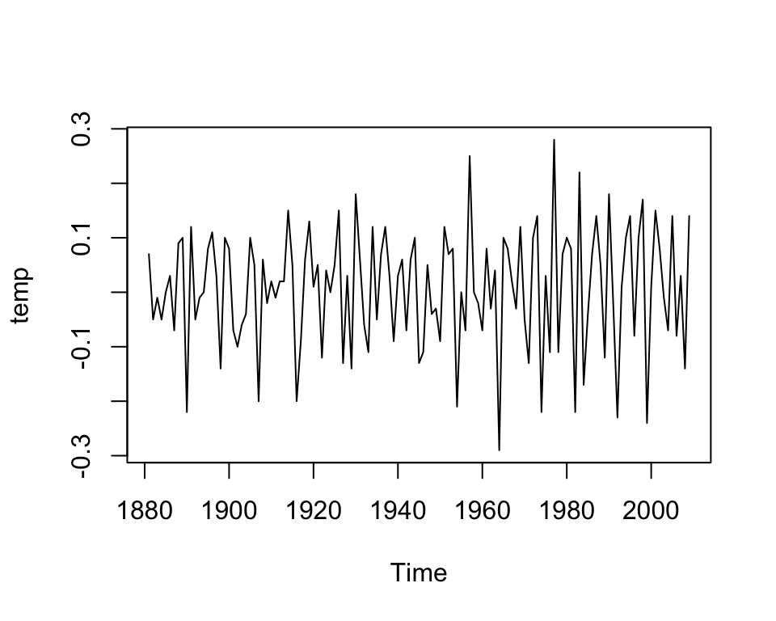

```r
  D  <- read.csv("http://gozips.uakron.edu/~nmimoto/pages/datasets/gtemp.csv")
  D1 <- ts(D, start=c(1880), freq=1)
  D2 <- diff(D1)

  plot(D2)
```

```r
  Fit1 <- ar(D2)

  Res <- Fit1$resid

  Box.test(Res,   lag = 15, type = "Ljung-Box")
```

```
##
##  Box-Ljung test
##
## data:  Res
## X-squared = 8.4903, df = 15, p-value = 0.9026
```

```r
  Box.test(Res,   lag = 20, type = "Ljung-Box")
```

```
##
##  Box-Ljung test
##
## data:  Res
## X-squared = 13.195, df = 20, p-value = 0.8689
```

```r
  Box.test(Res,   lag = 25, type = "Ljung-Box")
```

```
##
##  Box-Ljung test
##
## data:  Res
## X-squared = 15.097, df = 25, p-value = 0.9391
```

## Example: Null Distribution of L-B test

```r
  X <- rnorm(100, 2, 4)

  Box.test(Res, lag=15, type="Ljung-Box")

  Q <- n*(n+2)*sum( A1[2:16]^2/(n-(1:15)) )

  Q <- 0
  for (i in 1:1000) {
    X <- rnorm(100, 2, 4)
    sam.acf <- acf(X)$acf
    Q[i] <- n*(n+2)*sum( sam.acf[2:16]^2/(n-(1:15)) )
  }

  hist(Q, freq=FALSE)
  t <- seq(0, 50, .1)
  lines(t, dchisq(t, 15), col="red")
```

## McLeod-Li test

Instead of testing $Y_t$, test $Y_t^2$ for uncorrelation.

Use same test statistic as Ljung-Box, replace $Y_t$ with $Y_t^2$.

With sample ACF of $Y_t^2$, $\hat \rho(h)$,
$$Q = n(n+2) \sum_{h=1}^H \frac{ \hat \rho(h)^2}{n-h}$$

## Example: McLeod-Li test

```r
  A <- Fit1$resid

  Box.test(A^2, lag = 15, type = "Ljung-Box")
```

```
##
##  Box-Ljung test
##
## data:  A^2
## X-squared = 12.93, df = 15, p-value = 0.6077
```

```r
  Box.test(A^2, lag = 20, type = "Ljung-Box")
```

```
##
##  Box-Ljung test
##
## data:  A^2
## X-squared = 16.492, df = 20, p-value = 0.6857
```

## Test for Normality

Given sequence $Y_t$, we want to test if it came from Normal distribution. ($\mu$ and $\si$ unspecified).

- q-q normal plot
- Jarque-Bera test

## qq-normal plot

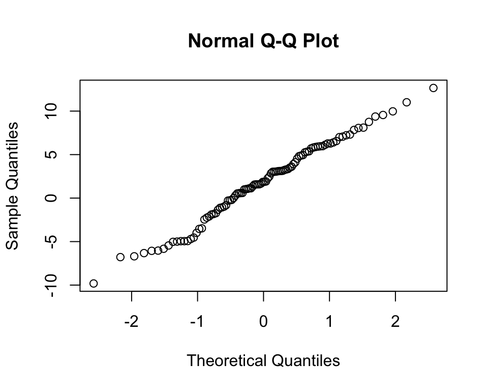

```r
  X <- rnorm(100, 2, 5)
  qqnorm(X)
```

## Jarque-Bera Test for Normality

- Normal distribution has skewness 0, and kurtosis of 3. for any $\mu$ and $\sigma^2$.

  $$\mbox{Skewness} = \frac{E[(Y_t - \mu )^3]}{ \mbox{SD}(Y_t)^{3}}
  \hspace10mm
  \mbox{ Kurtosis } = \frac{E[(Y_t - \mu )^4]}{ \mbox{SD}(Y_t)^{4}}$$
  $$JB = \frac{n}{6} \Big(S^2 + \frac{1}{4}(K-3)^2\Big)$$
  where $S$ is sample skewness, and $K$ is sample kurtosis.
- Asymptotically $JB$ has $\chi^2(2)$ distribution under the normality.

## Example: Testing Normality

```r
  library(tseries)  # load tseries package   ( install.packge("tseries") if first time)

  # acf(Res)
  # acf(Res, na.action=na.pass)
```

```r
  Res <- Fit1$resid
  Res <- Res[ which(is.na(Res)==0) ]    # remove NA from Ress

  jarque.bera.test(Res)
```

```
##
##  Jarque Bera Test
##
## data:  Res
## X-squared = 0.96684, df = 2, p-value = 0.6167
```

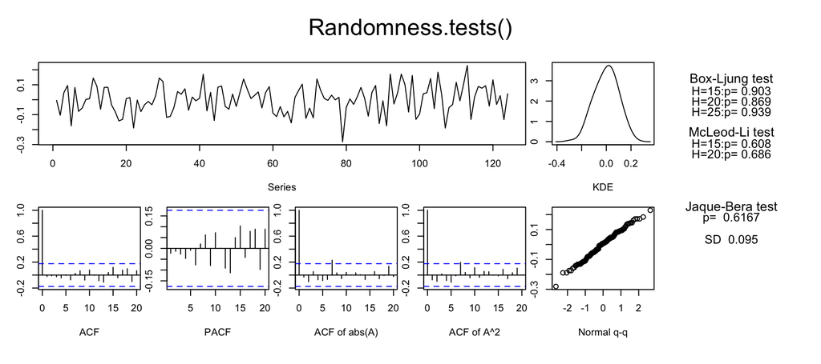

```
##   B-L test H0: the sereis is uncorrelated
##   M-L test H0: the square of the sereis is uncorrelated
##   J-B test H0: the sereis came from Normal distribution
##   SD         : Standard Deviation of the series
```

```
##       BL15  BL20  BL25  ML15  ML20    JB    SD
## [1,] 0.903 0.869 0.939 0.608 0.686 0.617 0.095
```

```r
  #--- This line copy and paste Basic Functions on class web page
  source("http://gozips.uakron.edu/~nmimoto/477/TS_R-90.txt")

  #- Use the function as below
  ehat <- Fit1$resid
  Randomness.tests(ehat)
```

## Making Function in R

```r
  x <- 5
  f <- exp(5+4)
  f

  f <- function(x){
    exp(x+4)
  }
  f(5)
```

# Summary

Residuals from any time-sereis analysis must be checked for:

- Randomness (for uncorrelation) - (e.g. Ljung-Box test)
- Heteroscedasticity (Randomness of squared series) - (e.g. McLeod-Li test)
- Normality - (e.g. qqplot and Jarque-Bera test)
- Below R code will load the all-in-one function (you need package installed already)

```r
  ehat <- Fit1$resid
  source("http://gozips.uakron.edu/~nmimoto/477/TS_R-90.txt")

  Randomness.tests(ehat)
```

- To test if the true mean is $0$ or not, we must construct CI for $\mu$, and see if $0$ is inside the CI or not.
- For autocorrelated data, variance of the sample mean is bigger than the random sample case. We must estimate the sample mean variance by summing up sample ACVF.